# ~ Project 4 ~

#### Check who has the highest p1 prediction 1.0

```python
# highest p1_conf
df[df.p1_conf == 1.0] #It's `not dog` named Shaggy (Spanish Water Dog) and a p1 prediction 1.0
```

|  | tweet_id | timestamp | text | rating_numerator | rating_denominator | name | dog_stage | retwt_cnt | fav_cnt | jpg_url | ... | p1 | p1_conf | p1_dog | p2 | p2_conf | p2_dog | p3 | p3_conf | p3_dog | p_class |
| --- | --- | --- | --- | --- | --- | --- | --- | --- | --- | --- | --- | --- | --- | --- | --- | --- | --- | --- | --- | --- | --- |
| 1866 | 667866724293877760 | 2015-11-21 00:46:50 | This is Shaggy. He knows exactly how to solve ... | 10.0 | 10.0 | Shaggy | NaN | 1110 | 3172 | https://pbs.twimg.com/media/CUS9PlUWwAANeAD.jpg | ... | Jigsaw Puzzle | 1.0 | False | Prayer Rug | 1.011300e-08 | False | Doormat | 1.740170e-10 | False | not dog |

1 rows × 21 columns

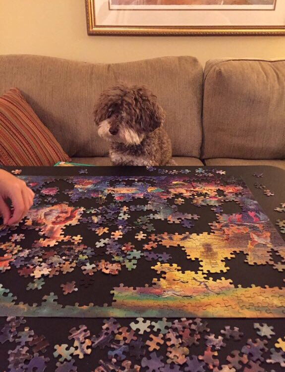

```python
# Picture of the `not dog` (but actually a dog) with the highest p1 prediction
Image('https://pbs.twimg.com/media/CUS9PlUWwAANeAD.jpg')
```

#### So of the 1971 entries in the `twitter_archive_master` dataset, 305 entries were misclassified as `not dog`, 472 as `hybrid` (i.e. `may be dog`). Only 1194 were correctly classified as `dog` yet none attains the highest p1 predection of 1. Ironically, the `not dog` has the highest prediction confidence of 1.

#### The numbers represent a 60.58% (=1194/1971 x 100%) chance the model correctly identifies a dog as a dog. Obviously, the model has more room for improvement.

## 4. Conclusion

We went through Data Wrangling process by

> - firstly gathering data from a variety of on and offline sources and in a variety of formats. The main dataset **`Enhance Twitter Archive`** which is provisioned by Udacity, contains dog ratings from the popular Twitter WeRateDogs rating provider. However, it was missing important elements like favorite and retweet counts, which fortunately can be scraped from Twitter site via an API provisioned by Twitter. Nonetheless, Twitter site is constantly aging out old tweets, so some of the required entries are no longer available for scrapping. To get around this, we resorted to loading an archived version of Twitter dataset **`tweet_json.txt`** provisioned by Udacity. Udacity also provisioned another dataset **`Image Predictions File`** that can be used to run every image from the **`Enhance Twitter Archive`** to get the top 3 predictions of the dog breed, providing the image is not older than August 1, 2017.
> - secondly assessing the data **visually and programmatically** to identify potential data tidiness and quality issues that would be preventing any meaningful data insight analysis from happening. All the issues identified are documented in a list for cleaning.
> - thirdly cleaning the data issues documented. Each issue was **prescribed a code fix, followed by execution and testing of the code fix**.
> - Forthly, combining the 3 cleansed datasets into **one single master dataset** and storing it **to a csv file and a python SQL database**.
> - Lastly, loading the master dataset and **conducting various data insight analysis and visualization** on the wrangled data to produce a report documenting the wrangling effort and another, communicating 3 insights (pertaining to favorite and retweet counts with respect to time, classification of dog species, and performance of the dog image classifier) along with related visualizations to compliment the insights.

# References

### Udacity Data Wrangling

[Lesson 1-11 : Gather (CSV Files)](https://youtu.be/FpWi4tExVwg)

[Lesson 1-14 : Assess: Intro](https://youtu.be/mdrAdtziXh4)

[Lesson 1-20 : Clean (Define)](https://youtu.be/qHB4jsqcfi4)

[Lesson 1-27 : Analysis and Visualization](https://youtu.be/OF2486euiRE)

[Lesson 2-12 : Downloading Files from the Internet](https://youtu.be/UceKUJ07Bn8)

[Lesson 2-15 : Source: APIs (Application Programming Interfaces](https://youtu.be/1y_qjUMDsCw)

[Lesson 3-6 : Assessment: Types vs. Steps](https://youtu.be/oZmndg-BnPk)

[Lesson 4-11 : Cleaning for Tidiness](https://youtu.be/6nMKFhpVCRU)

[Lesson 4-14 : Cleaning for Quality](https://youtu.be/qyixEwMRtWA)

### Miscellaneous Online References

[Pandas DataFrame indexing](https://brohrer.github.io/dataframe_indexing.html)

[What is the difference between json.load() and json.loads() functions](https://stackoverflow.com/questions/39719689/what-is-the-difference-between-json-load-and-json-loads-functions)

[`melt` tutorial](https://deparkes.co.uk/2016/10/28/reshape-pandas-data-with-melt/)

[`regex` tutorial](https://regexone.com/)

[Customizing Plots with Python Matplotlib](https://towardsdatascience.com/customizing-plots-with-python-matplotlib-bcf02691931f)

[Time Series Data Visualization with Python](https://machinelearningmastery.com/time-series-data-visualization-with-python/)

[Data Visualization with Seaborn (Part #3)](https://jovianlin.io/data-visualization-seaborn-part-3/)